# oyolasigmaz506portfolio_week12

Ozan Yolasigmaz

3/21/2019

## Purpose: K-means Cluster Analysis https://uc-r.github.io/kmeans_clustering

### Data preparation

```r
# read data
df <- USArrests
# omit NA values
df <- na.omit(df)
# scale data
df <- scale(df)
# and view example rows
head(df)
```

```
##                Murder   Assault   UrbanPop         Rape
## Alabama    1.24256408 0.7828393 -0.5209066 -0.003416473
## Alaska     0.50786248 1.1068225 -1.2117642  2.484202941
## Arizona    0.07163341 1.4788032  0.9989801  1.042878388
## Arkansas   0.23234938 0.2308680 -1.0735927 -0.184916602
## California 0.27826823 1.2628144  1.7589234  2.067820292
## Colorado   0.02571456 0.3988593  0.8608085  1.864967207
```

Different distance metrics we can use: Euclidean – what we consider as distance living on Earth, L2 norm Manhattan – adding together all the dimensions, L1 norm

Useful functions:

get_dist() # get distance between two rows of a matrix fviz_dist() # visualize distance matrix

The distance matrix for our data frame looks like the follows:

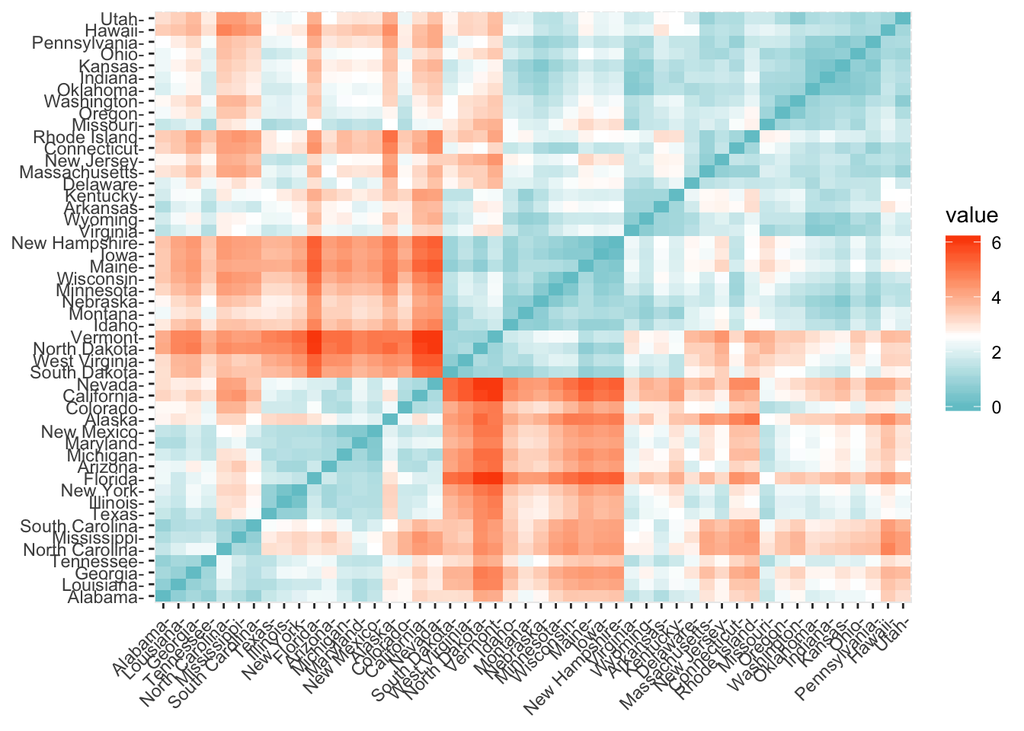

```r
distance <- get_dist(df)
fviz_dist(distance, gradient = list(low = "#00AFBB", mid = "white", high = "#FC4E07"))
```

### K-means clustering

In k-means clustering, our goal is to find k distinct center points so that when we consider the neighborhoods around these points, we have minimum total within-cluster sum of square.

To do so, we start with k arbitrary points, assign points to the closest one as their center, and move the centers through iteration until we have the minimum total within sum of square.

kmeans() # we will be using this function to run k-means clustering.

```r
k2 <- kmeans(df, centers = 2, nstart = 25)
str(k2)
```

```
## List of 9
##  $ cluster     : Named int [1:50] 2 2 2 1 2 2 1 1 2 2 ...
##   ..- attr(*, "names")= chr [1:50] "Alabama" "Alaska" "Arizona" "Arkansas" ...
##  $ centers     : num [1:2, 1:4] -0.67 1.005 -0.676 1.014 -0.132 ...
##   ..- attr(*, "dimnames")=List of 2
##   .. ..$ : chr [1:2] "1" "2"
##   .. ..$ : chr [1:4] "Murder" "Assault" "UrbanPop" "Rape"
##  $ totss       : num 196
##  $ withinss    : num [1:2] 56.1 46.7
##  $ tot.withinss: num 103
##  $ betweenss   : num 93.1
##  $ size        : int [1:2] 30 20
##  $ iter        : int 1
##  $ ifault      : int 0
##  - attr(*, "class")= chr "kmeans"
```

Here cluster is giving us which cluster each state belongs. We can now look at our results in more detail:

```r
k2
```

```
## K-means clustering with 2 clusters of sizes 30, 20
##
## Cluster means:
##      Murder    Assault   UrbanPop       Rape
## 1 -0.669956 -0.6758849 -0.1317235 -0.5646433
## 2  1.004934  1.0138274  0.1975853  0.8469650
##
## Clustering vector:
##        Alabama         Alaska        Arizona       Arkansas     California
##              2              2              2              1              2
##       Colorado    Connecticut       Delaware        Florida        Georgia
##              2              1              1              2              2
##         Hawaii          Idaho       Illinois        Indiana           Iowa
##              1              1              2              1              1
##         Kansas       Kentucky      Louisiana          Maine       Maryland
##              1              1              2              1              2
##  Massachusetts       Michigan      Minnesota    Mississippi       Missouri
##              1              2              1              2              2
##        Montana       Nebraska         Nevada  New Hampshire     New Jersey
##              1              1              2              1              1
##     New Mexico       New York North Carolina   North Dakota           Ohio
##              2              2              2              1              1
##       Oklahoma         Oregon   Pennsylvania   Rhode Island South Carolina
##              1              1              1              1              2
##   South Dakota      Tennessee          Texas           Utah        Vermont
##              1              2              2              1              1
##       Virginia     Washington  West Virginia      Wisconsin        Wyoming
##              1              1              1              1              1
##
## Within cluster sum of squares by cluster:
## [1] 56.11445 46.74796
##  (between_SS / total_SS =  47.5 %)
##
## Available components:
##
## [1] "cluster"      "centers"      "totss"        "withinss"
## [5] "tot.withinss" "betweenss"    "size"         "iter"
## [9] "ifault"
```

fviz_cluster() # will help us visualize these clusters

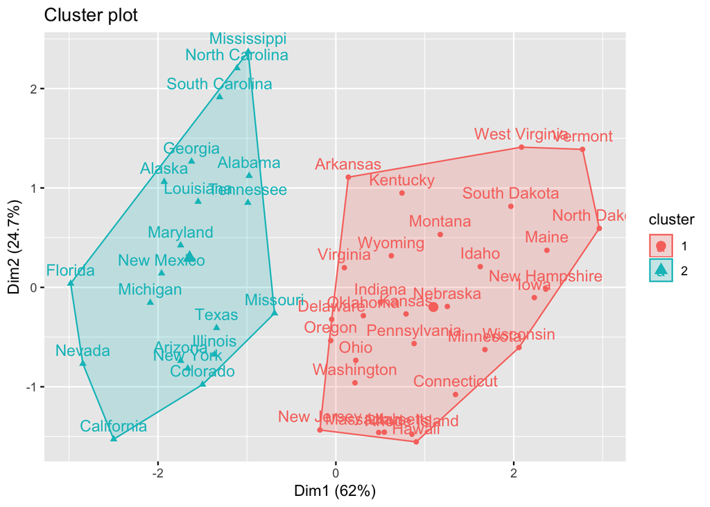

```r
fviz_cluster(k2, data = df)
```

Since we do not know the optimal number for k yet, let’s run k-means for a few different values of k.

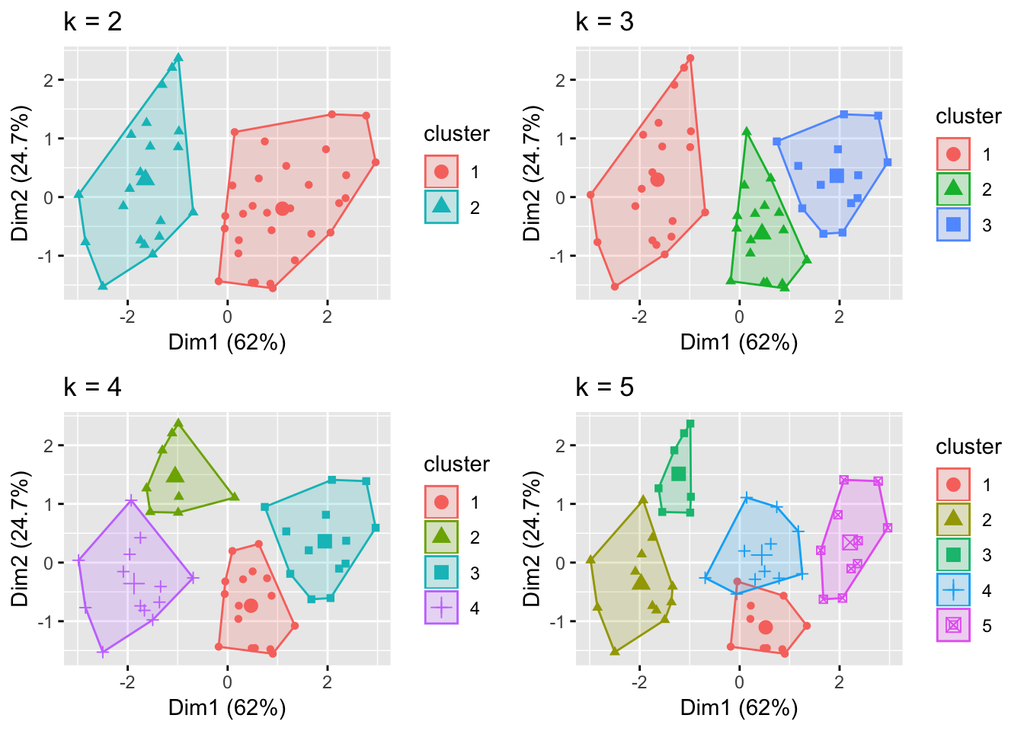

```r
k3 <- kmeans(df, centers = 3, nstart = 25)
k4 <- kmeans(df, centers = 4, nstart = 25)
k5 <- kmeans(df, centers = 5, nstart = 25)

# plots to compare
p1 <- fviz_cluster(k2, geom = "point", data = df) + ggtitle("k = 2")
p2 <- fviz_cluster(k3, geom = "point",  data = df) + ggtitle("k = 3")
p3 <- fviz_cluster(k4, geom = "point",  data = df) + ggtitle("k = 4")
p4 <- fviz_cluster(k5, geom = "point",  data = df) + ggtitle("k = 5")

grid.arrange(p1, p2, p3, p4, nrow = 2)
```

Now, we can focus on finding the optimal value for k.

### Determining Optimal Clusters

#### Elbow method

The goal with the elbow method is to find the value of k for which we are not lowering the total within-cluster sum of square (wss), or if it exists, the k for which it increases.

To do so, we need to define a function that allows us to compute wss easily:

```r
wss <- function(k) {
  kmeans(df, k, nstart = 10 )$tot.withinss
}
```

And now we can utilize this function to draw the elbow diagram:

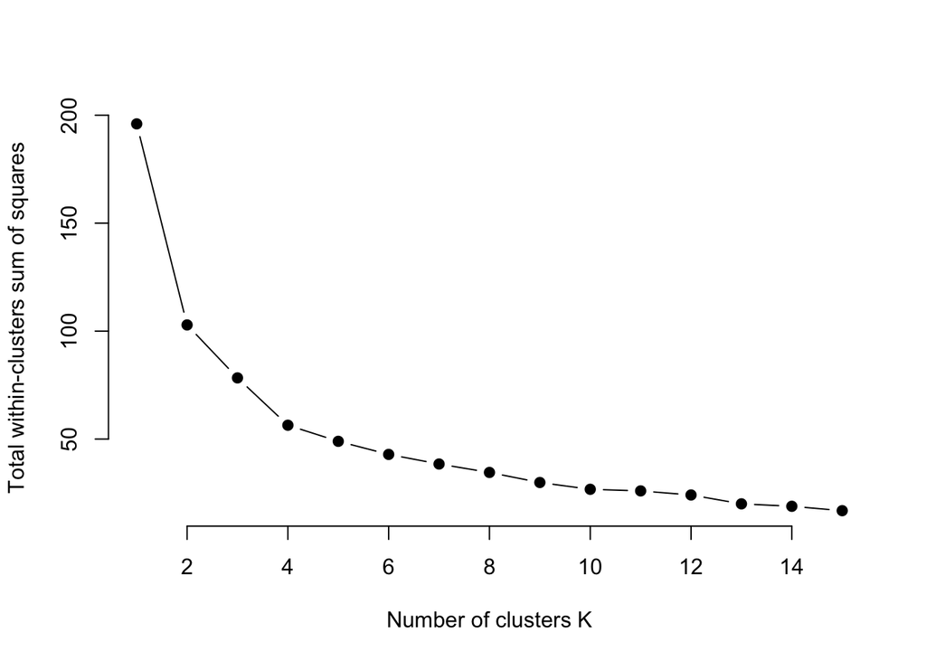

```r
# in order to reproduce our work in the future, we set the seed value
set.seed(100)

# we'll test for k from 1 to 15
k.values <- 1:15

# calculate wss values for each
wss_values <- map_dbl(k.values, wss)

plot(k.values, wss_values,
       type="b", pch = 19, frame = FALSE,
       xlab="Number of clusters K",
       ylab="Total within-clusters sum of squares")
```

Instead of running all this, we could also use the predefined function: fviz_nbclust() # produces the elbow graph

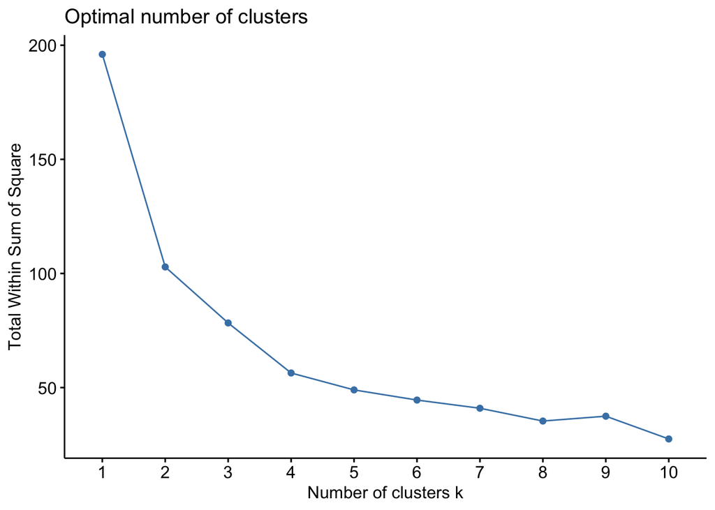

```r
fviz_nbclust(df, kmeans, method="wss")
```

#### Average Silhouette Method

This is another method for finding the optimal number of clusters, by measuring the quality of each cluster. To do so, we need the following function:

silhoutte() # calculates silhoutte for given clustering

First, we define a function to calculate average silhoute values:

```r
avg_sil <- function(k) {
  km.res <- kmeans(df, centers = k, nstart = 25)
  ss <- silhouette(km.res$cluster, dist(df))
  mean(ss[, 3])
}
```

And now, we can plot the average silhoutte values:

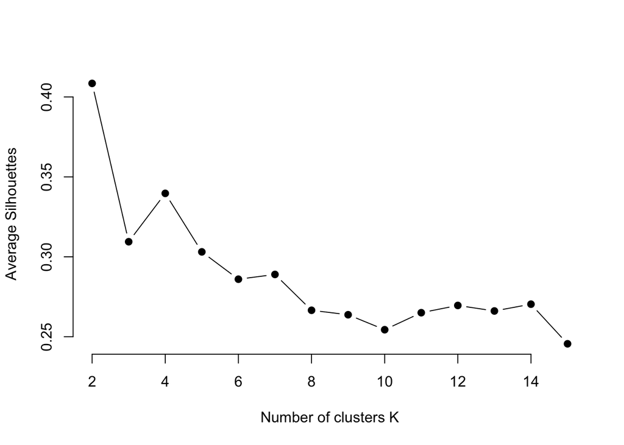

```r
# we'll try it for k between 2 and 15
k.values <- 2:15

# calculate average silhoutte values for each
avg_sil_values <- map_dbl(k.values, avg_sil)

# plot
plot(k.values, avg_sil_values,
       type = "b", pch = 19, frame = FALSE,
       xlab = "Number of clusters K",
       ylab = "Average Silhouettes")
```

#### Gap Statistic Method

The last method we’ll try is gap statistic method, and it calculates the total intracluster variation for a given clustering, and compares that to their expected values under null reference distribution of the data.

```r
gap_stat <- clusGap(df, FUN = kmeans, nstart = 25,
                    K.max = 10, B = 50)
# Print the result
print(gap_stat, method = "firstmax")
```

```
## Clustering Gap statistic ["clusGap"] from call:
## clusGap(x = df, FUNcluster = kmeans, K.max = 10, B = 50, nstart = 25)
## B=50 simulated reference sets, k = 1..10; spaceH0="scaledPCA"
##  --> Number of clusters (method 'firstmax'): 4
##           logW   E.logW       gap     SE.sim
##  [1,] 3.458369 3.639212 0.1808423 0.04135671
##  [2,] 3.135112 3.365666 0.2305544 0.03577438
##  [3,] 2.977727 3.230076 0.2523489 0.03770946
##  [4,] 2.826221 3.113019 0.2867982 0.03765622
##  [5,] 2.738868 3.016820 0.2779521 0.03950686
##  [6,] 2.666967 2.930984 0.2640166 0.04098201
##  [7,] 2.612957 2.854353 0.2413954 0.04131091
##  [8,] 2.531626 2.783431 0.2518051 0.04373836
##  [9,] 2.468162 2.716640 0.2484776 0.04581056
## [10,] 2.394884 2.653022 0.2581378 0.04563012
```

The following function allows us to visualize the results of this method: fviz_gap_stat() # vizualize gap statistic for given clustering

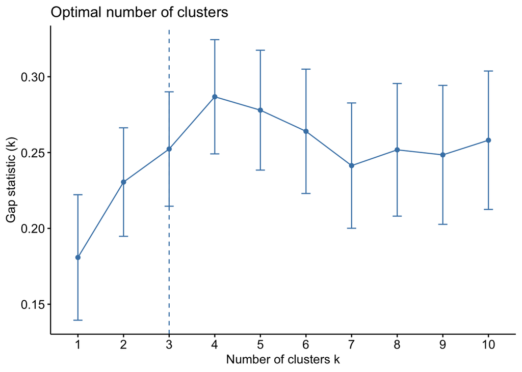

```r
fviz_gap_stat(gap_stat)
```

Now we can print out the final clustering, and visualize it:

```r
final <- kmeans(df, 4, nstart = 25)
print(final)
```

```
## K-means clustering with 4 clusters of sizes 8, 16, 13, 13
##
## Cluster means:
##       Murder    Assault   UrbanPop        Rape
## 1  1.4118898  0.8743346 -0.8145211  0.01927104
## 2 -0.4894375 -0.3826001  0.5758298 -0.26165379
## 3  0.6950701  1.0394414  0.7226370  1.27693964
## 4 -0.9615407 -1.1066010 -0.9301069 -0.96676331
##
## Clustering vector:
##        Alabama         Alaska        Arizona       Arkansas     California
##              1              3              3              1              3
##       Colorado    Connecticut       Delaware        Florida        Georgia
##              3              2              2              3              1
##         Hawaii          Idaho       Illinois        Indiana           Iowa
##              2              4              3              2              4
##         Kansas       Kentucky      Louisiana          Maine       Maryland
##              2              4              1              4              3
##  Massachusetts       Michigan      Minnesota    Mississippi       Missouri
##              2              3              4              1              3
##        Montana       Nebraska         Nevada  New Hampshire     New Jersey
##              4              4              3              4              2
##     New Mexico       New York North Carolina   North Dakota           Ohio
##              3              3              1              4              2
##       Oklahoma         Oregon   Pennsylvania   Rhode Island South Carolina
##              2              2              2              2              1
##   South Dakota      Tennessee          Texas           Utah        Vermont
##              4              1              3              2              4
##       Virginia     Washington  West Virginia      Wisconsin        Wyoming
##              2              2              4              4              2
##
## Within cluster sum of squares by cluster:
## [1]  8.316061 16.212213 19.922437 11.952463
##  (between_SS / total_SS =  71.2 %)
##
## Available components:
##
## [1] "cluster"      "centers"      "totss"        "withinss"
## [5] "tot.withinss" "betweenss"    "size"         "iter"
## [9] "ifault"
```

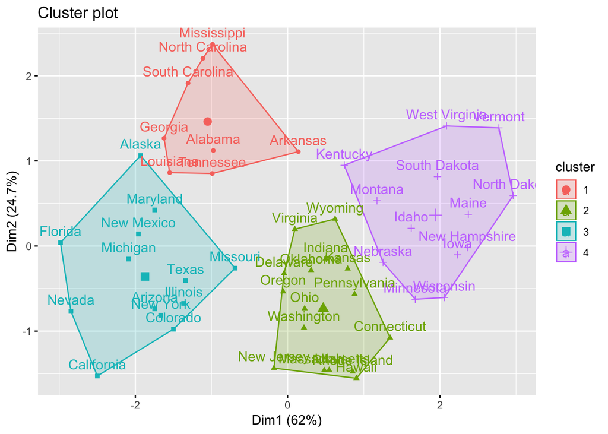

```r
fviz_cluster(final, data = df)
```

We can also assign the given clusters to the states in our original data set, and try to come up with descriptive statistics that can highlight the differences:

```r
USArrests %>%
  mutate(Cluster = final$cluster) %>%
  group_by(Cluster) %>%
  summarise_all("mean")
```

```
## # A tibble: 4 x 5
##   Cluster Murder Assault UrbanPop  Rape
##     <int>  <dbl>   <dbl>    <dbl> <dbl>
## 1       1  13.9    244.      53.8  21.4
## 2       2   5.66   139.      73.9  18.8
## 3       3  10.8    257.      76    33.2
## 4       4   3.6     78.5     52.1  12.2
```